# Visualising Brexit Votes with Leaflet and Rcartogram

As one of the first posts on my shiny new blog, I give you data visualisation (of course, what’s more crowd pleasing than that?)

### “What’s the topic?”

The [2016 Brexit catastrophy](https://en.wikipedia.org/wiki/United_Kingdom_European_Union_membership_referendum,_2016) (a.k.a. United Kingdom European Union membership referendum, 2016) is slowly releasing its venom as the negotiations on the terms proceed between the UK and the EU.

To add to the insult I thought I’d visualise the votes.

### “Why are you doing it again?”

I hear you say, “after [so](http://www.bbc.co.uk/news/uk-politics-36616028) [many](https://medium.com/@jakeybob/brexit-maps-d70caab7315e#.k8mztsqz1) [have](http://www.telegraph.co.uk/news/0/leave-or-remain-eu-referendum-results-and-live-maps/) [done](http://www.thepoke.co.uk/2017/01/13/post-brexit-map-uk-accurate-funny/) it, most likely better than you could, ever!” Well, I could hardly disagree. Consider this then a self-indulging exercise in combining these techniques:

- **Shapefile** - a ubiquitous geospatial vector data format. I shall demonstrate the ease of manipulating the file with R.
- **Cartogram** - a mapping distortion technique for representing geographic data in a striking way.
- **Hexagon** - a type of mapping distortion focused on representing geographic units with a uniform area size.
- **Leaflet** - a modern and popular Javascript package for visualsation in the browser.
- **R Notebook** - the latest and greatest document format for code sharing from RStudio.

### “So what? What benefit does combining all that give you?”

Good question, one that should be asked before any data analysis is carried out. Here are my answers.

#### Shapefile

After some searching I have only found a couple of sources for UK hexagon maps ([Parliamentary Constituencies](http://www.arcgis.com/home/item.html?id=15baaa6fecd54aa4b7250780b6534682) and [Local Authorities](http://www.arcgis.com/home/item.html?id=593037bc399e460bb7c6c631ceff67b4) along with a [tool](https://www.arcgis.com/home/item.html?id=d348614c97264ae19b0311019a5f2276) to create them) published by Esri (while there are plenty for the US, e.g. the [`tilegramsR`](https://rpubs.com/bhaskarvk/tilegramsR) package gives you several beautiful options).

The votes data is aggregated to the Local Authority level, so the corresponding shapefile shall be used.

#### Hexagon cartogram

Cartogram is a great way to emphasise data features on a map. However in the case of the UK, there are close to 400 local authorities, plotting them all on the with their distorted irregular shapes would not be so visually pleasant or informative. When the starting point is a hexagon cartogram, however, the features are laid out in a regular grid, after distortion it is much easier on the eyes.

#### Leaflet

Faced with a map of a crowded bunch of colour shapes, one’s first instinct (especially if you live in the UK hence more familiar with the geography) would be to work out which shape respresents which Local Authority, and the only way is of course an interactive map that can show you the name (and the vote count) of a shape if you hover the cursor over it. This is a no brainer.

#### R Notebook

Just because it is new and I can.

The result fulfils my desire of the past few months: to visualise the impact of different voting populations in granular geo-aggregates, and revealing to certain extent the population distribution related to some demographic features.

### “Go on then, get on with it.”

Yes, sir.

#### The votes data

The data source is [The Electoral Commssion](http://www.electoralcommission.org.uk/find-information-by-subject/elections-and-referendums/past-elections-and-referendums/eu-referendum/electorate-and-count-information) and the CSV can be downloaded directly from [here](http://www.electoralcommission.org.uk/__data/assets/file/0014/212135/EU-referendum-result-data.csv).

```r
csv_url <- 'http://www.electoralcommission.org.uk/__data/assets/file/0014/212135/EU-referendum-result-data.csv'
# For reproducibility the CSV is also downloaded in the data/ folder
# download.file(url = csv_url, destfile = paste0('./data/', regmatches(csv_url, regexpr('[^/]+$', csv_url))))
raw_votes <- read.csv(csv_url, stringsAsFactors = F)
# Create names_votes to match against the shape file later
names_votes <- raw_votes$Area
```

#### The hexagon shapefile

|  | OBJECTID | LAD12CD | LAD12NM | Shape_Leng | Shape_Area |
| --- | --- | --- | --- | --- | --- |
| 0 | 1 | E07000205 | Suffolk Coastal | 127685.1 | 1176601978 |
| 1 | 2 | E07000202 | Ipswich | 127686.2 | 1176622756 |
| 2 | 3 | E07000076 | Tendring | 127685.7 | 1176613311 |
| 3 | 4 | E07000145 | Great Yarmouth | 127685.8 | 1176614926 |
| 4 | 5 | E07000206 | Waveney | 127685.4 | 1176607876 |
| 5 | 6 | E07000203 | Mid Suffolk | 127686.5 | 1176628446 |

Let’s plot it against an actual map to get a sense of it. To do that let’s project it to WGS84 (`EPSG:4326`) measured in degrees of latitude / longitude, which also allows to set up the bouding box easier.

*Note: using ggplot to overlay polygons on a map requires turning the shapefile into a data frame by using `broom::tidy()`. After running the function if you encounter this error `Error: isTRUE(gpclibPermitStatus()) is not TRUE` on Windows, make sure Rtools is installed, then install package `gpclib` using `install.packages('gpclib', type = 'source')`. To verify everything is fine, run `gpclibPermitStatus()` and `gpclibPermit()`, if both return `True` then you are all set.*

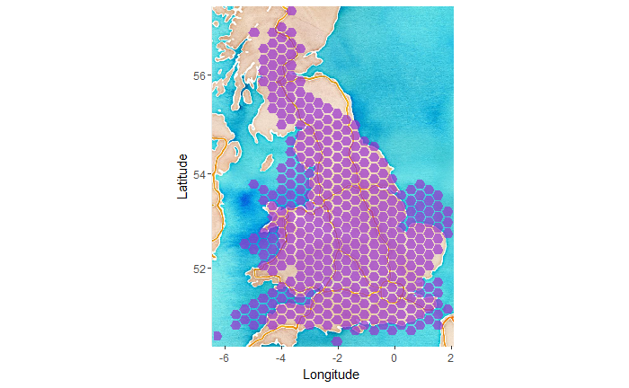

```r
basemap <- ggmap(
  get_map(location = b,
          source = "stamen",
          maptype = "watercolor",
          crop = T))
basemap + geom_polygon(
  data = la_84_df,
  aes(x = long, y = lat, group = group),
  fill = 'darkorchid',
  alpha = 0.7) + xlab('Longitude') + ylab('Latitude')
```

So the hexagon map is roughly based on the actual coordicates of the features.

But wait, the Local Authority shapefile has a flaw - it is missing Northern Ireland and Gibraltar, confirmed by comparing the names from the CSV and the shapefile (The Vale of Glamorgan also has different names in the two files, let’s deal with that later)

```r
setdiff(names_votes, names_shp)
```

```
[1] "Northern Ireland"  "Gibraltar"         "Vale of Glamorgan"
```

```r
setdiff(names_shp, names_votes)
```

```
[1] "The Vale of Glamorgan"
```

Let’s create them!

The plan is to create NI and GI features by copying one of the polygons near by, shift it to an appropriate location, and update the attributes and data to reflect NI and GI respectively. So I decided using the British National Grid projection (`EPSG:27700`), as measured in meters, would be a better choice, as the shift can be explicit and more understandable.

Barrow-in-Furness is a good choice as a neighbouring polygon. NI is esitmated to be 100,000 meters to the west, and GI is 600,000 meters to the south of NI.

```r
la_bng <- spTransform(la_shp, CRS('+init=epsg:27700'))
ind_ref <- which(la_bng$LAD12NM == 'Barrow-in-Furness')
ni <- la_bng@polygons[[ind_ref]]
ni_coors <- ni@Polygons[[1]]@coords
# NI seems around 150,000 meters to the west
# GI 500,000 meters to the south
ni_shiftx <- -100000
gi_shifty <- -600000
# Shape coordinates
ni_coors[, 1] <- ni_coors[, 1] + ni_shiftx
gi_coors <- ni_coors
gi_coors[, 2] <- ni_coors[, 2] + gi_shifty
# Labpt coordinates
ni_labpt_x <- ni@labpt[1] - ni_shiftx
ni_labpt_y <- ni@labpt[2]
ni_labpt <- c(ni_labpt_x, ni_labpt_y)
gi_labpt_x <- ni@labpt[1] + ni_shiftx
gi_labpt_y <- ni@labpt[2] + gi_shifty
gi_labpt <- c(gi_labpt_x, gi_labpt_y)
# Replace coordiates and ID in ni and gi
ni_poly <- ni
gi_poly <- ni
ni_poly@Polygons[[1]]@coords <- ni_coors
gi_poly@Polygons[[1]]@coords <- gi_coors
ni_poly@Polygons[[1]]@labpt <- ni_labpt
gi_poly@Polygons[[1]]@labpt <- gi_labpt
ni_poly@labpt <- ni_labpt
gi_poly@labpt <- gi_labpt
new_poly_ids <- c('380', '381')
ni_poly@ID <- new_poly_ids[1]
gi_poly@ID <- new_poly_ids[2]
# Construct the new SpatialPolygons
la_bng_polygons <- c(la_bng@polygons, ni_poly, gi_poly)
la_bng_spgs <- SpatialPolygons(la_bng_polygons)
proj4string(la_bng_spgs) <- proj4string(la_bng)
# Construct the new SpatialPolygonsDataFrame
ni_lad12cn <- raw_votes[raw_votes$Area == 'Northern Ireland', 'Area_Code']
gi_lad12cn <- raw_votes[raw_votes$Area == 'Gibraltar', 'Area_Code']
new_data <- data.frame(
  OBJECTID = c('380', '381'),
  LAD12CD = c(ni_lad12cn, gi_lad12cn),
  LAD12NM = c('Northern Ireland', 'Gibraltar'),
  Shape_Leng = mean(la_bng$Shape_Leng),
  Shape_Area = mean(la_bng$Shape_Area))
la_new_data <- rbind(la_bng@data, new_data)
rownames(la_new_data)[(nrow(la_new_data) - 1):nrow(la_new_data)] <- new_poly_ids
la_bng_new <- SpatialPolygonsDataFrame(la_bng_spgs, la_new_data)
```

Let’s check that the polygons have indeed been created:

[output not shown]

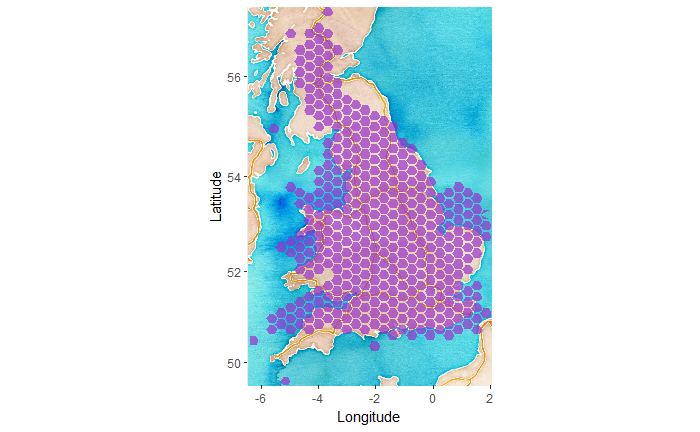

```r
la_84_new <- spTransform(la_bng_new, CRS('+init=epsg:4326'))
la_84_new_df <- la_84_new %>% tidy(region = "LAD12NM")
ggmap(
  get_map(location = bbox(la_84_new),
          source = "stamen",
          maptype = "watercolor",
          crop = T)) +
  geom_polygon(
    data = la_84_new_df,
    aes(x = long, y = lat, group = group),
    fill = 'darkorchid',
    alpha = 0.7) + xlab('Longitude') + ylab('Latitude')
```

Much better.

### First star of the show - `Rcartogram`

```r
## On command line in OS/X with homebrew.
## Wrapped in FALSE statement to not run system() unintentionally
if (FALSE) {
  system("brew install fftw")
}
Sys.setenv(FFTW3_DIR="C:/ProgramData/fftw/x64")
devtools::install_github("omegahat/Rcartogram")
Sys.unsetenv("FFTW3_DIR")
devtools::install_github('chrisbrunsdon/getcartr', subdir='getcartr')
```

```r
library(Rcartogram)
```

[output not shown]

```r
pacman::p_load(ggplot2)
ggplot(data = raw_votes,
       aes(x = Pct_Remain, fill = Region, col = Region)) +
  geom_density(alpha = 0.5) + theme_bw() +
  xlim(0, 100) + ylim(0, 0.09) +
  geom_vline(aes(xintercept = 50)) +
  facet_wrap(~Region) + theme(legend.position="none") +
  xlab('Percentage of Remain votes') +
  ylab('Distribution density') +
  ggtitle('Remain vote distribution by Region')
```

[output not shown]

So we must not lose the information on the map. In addition to that, aren’t you just dying to work out which area is which? Let’s get straight down to `leaflet` to address all of the above.

### The other star - `leaflet`

```r
la_bng_new$Valid_Votes_sq <- la_bng_new$Valid_Votes ^ 2
carto_x <- cartogram(la_bng_new, 'Valid_Votes_sq')
carto_x$fill_op <- abs(carto_x$Pct_Remain - 50) / max(abs(carto_x$Pct_Remain - 50))
labels2 <- sprintf(
  '<strong>%s</strong><br/>Remain: %s (%.0f%%)<br/>Leave: %s (%.0f%%)',
  carto$LAD12NM,
  prettyNum(carto$Remain, big.mark = ','), 100 * carto$Remain / carto$Valid_Votes,
  prettyNum(carto$Leave, big.mark = ','), 100 * carto$Leave / carto$Valid_Votes
) %>% lapply(htmltools::HTML)

leaflet(carto_x, options = leafletOptions(crs = epsg4326)) %>%
  addPolygons(
    color = "#444444", weight = 1, smoothFactor = 0.5,
    label = labels2,
    opacity = 1.0, fillOpacity = carto_x$fill_op, fillColor = cols[as.factor(carto_x$Result)],
    highlightOptions = highlightOptions(color = "white", weight = 2, bringToFront = TRUE))


# ggplot the ^2 version
carto_x_df <- carto_x %>% tidy(region = 'LAD12NM')
carto_x_df <- carto_x_df %>%
  left_join(
    data.frame(id = as.character(la_bng_new$LAD12NM),
               Result = as.factor(la_bng_new$Result),
               stringsAsFactors = F))
png('./output/brexit3.png')
ggplot() + theme_bw() + theme_nothing(legend = TRUE) + coord_fixed() +
  geom_polygon(data = carto_x_df, aes(x = long, y = lat, group = id, fill = Result, colour = Result))
dev.off()
```

[output not shown]

### Other cartogram related packages

- [`topogRam`](https://github.com/pvictor/topogRam) - a `d3.js` based package